# Tidying and Transforming Data

Mohammed Rahman

2023-03-06

[GitHub Link to Rmd file](https://github.com/mrcuny/tidying-and-transforming-data/blob/main/tidying-and-transforming-data.Rmd)

Load libraries to use:

```r
library(dplyr)
library(tidyr)
library(ggplot2)
```

## Task 1

Task: Create a .CSV file (or optionally, a MySQL database!) that includes all of the information above. You’re encouraged to use a “wide” structure similar to how the information appears above, so that you can practice tidying and transformations as described below.

### Solution

Create a dataframe that includes all of the information:

```r
arrival_delays <- tibble(
  airline = rep(c("ALASKA", "AM WEST"), each = 2),
  arrival = rep(c("on time", "delayed"), times = 2),
  los_angeles = c(497, 62, 694, 117),
  phoenix = c(221, 12, 4840, 415),
  san_diego = c(212, 20, 383, 65),
  san_francisco = c(503, 102, 320, 129),
  seattle = c(1841, 305, 201, 61)
)

arrival_delays
```

```
## # A tibble: 4 × 7
##   airline arrival los_angeles phoenix san_diego san_francisco seattle
##   <chr>   <chr>         <dbl>   <dbl>     <dbl>         <dbl>   <dbl>
## 1 ALASKA  on time         497     221       212           503    1841
## 2 ALASKA  delayed          62      12        20           102     305
## 3 AM WEST on time         694    4840       383           320     201
## 4 AM WEST delayed         117     415        65           129      61
```

Create a csv file to hold all the information above:

```r
write.csv(x = arrival_delays, file = "arrival-delays.csv", row.names = FALSE)
```

## Task 2

Task: Read the information from your .CSV file into R, and use tidyr and dplyr as needed to tidy and transform your data.

### Solution

Read the information from the csv file into R:

```r
arrival_delays <- read.csv(file = "arrival-delays.csv")

arrival_delays
```

```
##   airline arrival los_angeles phoenix san_diego san_francisco seattle
## 1  ALASKA on time         497     221       212           503    1841
## 2  ALASKA delayed          62      12        20           102     305
## 3 AM WEST on time         694    4840       383           320     201
## 4 AM WEST delayed         117     415        65           129      61
```

The next step is to tidy the data so that it is in the correct format. In this case, we want to convert the data from wide to a long format:

```r
arrival_delays_tidy <- arrival_delays %>%
  pivot_longer(
    cols = c(los_angeles, phoenix, san_diego, san_francisco, seattle),
    names_to = "city",
    values_to = "delay_minutes"
  )

arrival_delays_tidy
```

```
## # A tibble: 20 × 4
##    airline arrival city          delay_minutes
##    <chr>   <chr>   <chr>                 <int>
##  1 ALASKA  on time los_angeles             497
##  2 ALASKA  on time phoenix                 221
##  3 ALASKA  on time san_diego               212
##  4 ALASKA  on time san_francisco           503
##  5 ALASKA  on time seattle                1841
##  6 ALASKA  delayed los_angeles              62
##  7 ALASKA  delayed phoenix                  12
##  8 ALASKA  delayed san_diego                20
##  9 ALASKA  delayed san_francisco           102
## 10 ALASKA  delayed seattle                 305
## 11 AM WEST on time los_angeles             694
## 12 AM WEST on time phoenix                4840
## 13 AM WEST on time san_diego               383
## 14 AM WEST on time san_francisco           320
## 15 AM WEST on time seattle                 201
## 16 AM WEST delayed los_angeles             117
## 17 AM WEST delayed phoenix                 415
## 18 AM WEST delayed san_diego                65
## 19 AM WEST delayed san_francisco           129
## 20 AM WEST delayed seattle                  61
```

Let’s also rename the `arrival` column and convert it from a character string to a logical value and rename it:

```r
arrival_delays_tidy <- arrival_delays_tidy %>%
  rename(is_delayed = arrival) %>%
  mutate(is_delayed = ifelse(is_delayed == "delayed", TRUE, FALSE))

arrival_delays_tidy
```

```
## # A tibble: 20 × 4
##    airline is_delayed city          delay_minutes
##    <chr>   <lgl>      <chr>                 <int>
##  1 ALASKA  FALSE      los_angeles             497
##  2 ALASKA  FALSE      phoenix                 221
##  3 ALASKA  FALSE      san_diego               212
##  4 ALASKA  FALSE      san_francisco           503
##  5 ALASKA  FALSE      seattle                1841
##  6 ALASKA  TRUE       los_angeles              62
##  7 ALASKA  TRUE       phoenix                  12
##  8 ALASKA  TRUE       san_diego                20
##  9 ALASKA  TRUE       san_francisco           102
## 10 ALASKA  TRUE       seattle                 305
## 11 AM WEST FALSE      los_angeles             694
## 12 AM WEST FALSE      phoenix                4840
## 13 AM WEST FALSE      san_diego               383
## 14 AM WEST FALSE      san_francisco           320
## 15 AM WEST FALSE      seattle                 201
## 16 AM WEST TRUE       los_angeles             117
## 17 AM WEST TRUE       phoenix                 415
## 18 AM WEST TRUE       san_diego                65
## 19 AM WEST TRUE       san_francisco           129
## 20 AM WEST TRUE       seattle                  61
```

## Task 3

Task: Perform analysis to compare the arrival delays for the two airlines

### Solution

Since the data is now tidy, we can use `dplyr` to transform it as necessary.

Let’s calculate the average delay time by airline using the `groupby` and `summarize` functions:

```r
arrival_delay_by_airline <- arrival_delays_tidy %>%
  group_by(airline) %>%
  summarize(
    avg_delay = mean(delay_minutes),
    delayed_flights = sum(is_delayed)
  )

arrival_delay_by_airline
```

```
## # A tibble: 2 × 3
##   airline avg_delay delayed_flights
##   <chr>       <dbl>           <int>
## 1 ALASKA       378.               5
## 2 AM WEST      722.               5
```

We can see that on average, even though both airlines have the same number of delayed flights, AM WEST has a higher average arrival delay (722.5) as compared to ALASKA (377.5)

We can as well group the data by airline and city and use a bar plot to visualize the average delay time for each airline and city:

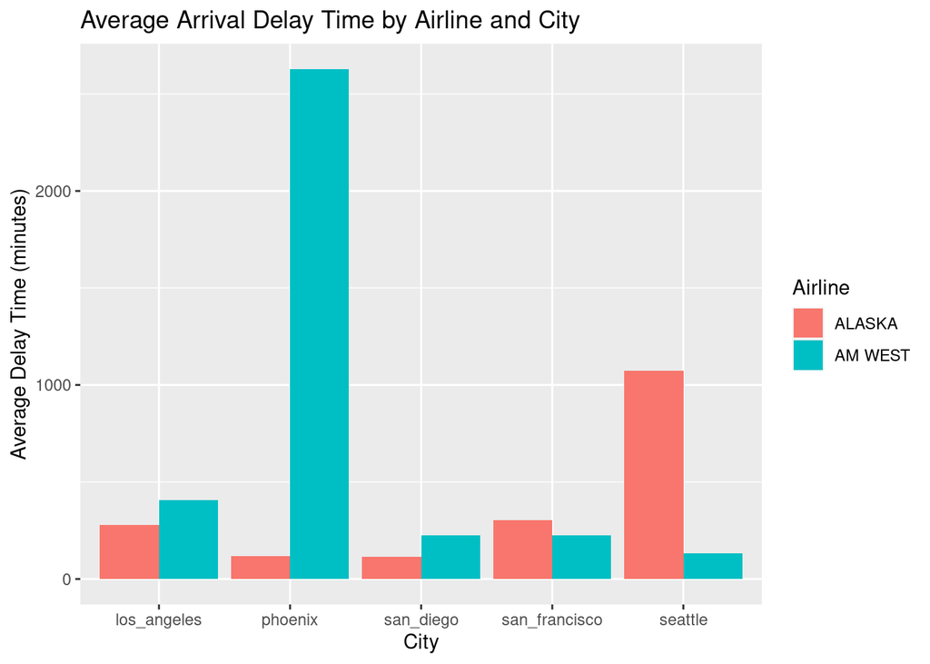

```r
arrival_delays_summary <- arrival_delays_tidy %>%
  group_by(airline, city) %>%
  summarize(
    avg_delay = mean(delay_minutes),
    delayed_flights = sum(is_delayed)
  )

ggplot(arrival_delays_summary, aes(x = city, y = avg_delay, fill = airline)) +
  geom_col(position = "dodge") +
  labs(title = "Average Arrival Delay Time by Airline and City",
       x = "City", y = "Average Delay Time (minutes)",
       fill = "Airline")
```

Phoenix seems to have the highest average arrival delay time.

Factors such as time of day and weather conditions may be causing these delays.

## Conclusions

In this task, we started with a messy data set of arrival delay times for two airlines across five different cities. We used the tidyr and dplyr libraries in R to tidy and transform the data into a more usable format.

In conclusion, by cleaning and analyzing the data, we were able to identify differences in the arrival delay times between the two airlines and gain insights into potential factors that may be causing these delays. This information can be used to improve the airline’s performance and provide a better experience for passengers.